# Data Exploration

Isabella Escamilla

## Introduction

While working with this data set, I noticed a few problems.

- **Scaling**: Since there are so many different data sources, the different scaling of the data sources makes it unreliable if I were to aggregate them by taking averages. A potential solution is to normalize the data from each source and track the changes between years, but I’m not too sure about that approach.
- **Random Months**: In order to fully use the data in this set, I have to find a way to work with the randomness of the months. For example, many of the data sources include random selections of months for each year and it doesn’t include every month. I feel like there is a way to still use this data, but I will either have to inpute the in-between months or something. After some online research, I learned that there is a “zoo” object that allows you to have different dates for each observation, and I wonder if I’d be able to use that to fit SARIMA or do spectral analysis.
- **Missing Data**: Again, there are a lot of different sources. Some of these sources have a lot of missing data, and R does not allow me to make a time series object with missing data. This goes along with a previous problem of there being a random selection of months.

```r
dataloc <- './DataSource/data/InsectAbundanceBiomassData.csv'
data <- read.csv(dataloc)
summary(data)
```

```
##  DataSource_ID     Plot_ID       Stratum            MetricAB
##  Min.   :  63   Min.   :   1   Length:70955       Length:70955
##  1st Qu.:1263   1st Qu.: 375   Class :character   Class :character
##  Median :1444   Median : 904   Mode  :character   Mode  :character
##  Mean   :1231   Mean   : 917
##  3rd Qu.:1487   3rd Qu.:1426
##  Max.   :1527   Max.   :1872
##
##     Period               Year          Number
##  Length:70955       Min.   :1925   Min.   :      0
##  Class :character   1st Qu.:1995   1st Qu.:      4
##  Mode  :character   Median :2003   Median :     32
##                     Mean   :2001   Mean   :   1963
##                     3rd Qu.:2010   3rd Qu.:    188
##                     Max.   :2018   Max.   :5005000
##                                    NA's   :9955
```

```r
data2 <- data %>% filter(DataSource_ID == 1476)
head(data2, 10)
```

```
##    DataSource_ID Plot_ID Stratum  MetricAB Period Year    Number
## 1           1476     286     Air abundance      7 1997 170.98797
## 2           1476     286     Air abundance      8 1998  68.39519
## 3           1476     286     Air abundance      7 1999  66.38356
## 4           1476     286     Air abundance      8 1999  56.32545
## 5           1476     286     Air abundance      4 1999   0.00000
## 6           1476     286     Air abundance      4 2000   0.00000
## 7           1476     286     Air abundance      8 2000  22.12785
## 8           1476     286     Air abundance      5 2001   0.00000
## 9           1476     286     Air abundance      8 2001 414.39437
## 10          1476     286     Air abundance      9 2001 140.81362
```

```r
data3 <- data %>% filter(DataSource_ID == 249)
head(data3, 10)
```

```
##    DataSource_ID Plot_ID Stratum  MetricAB Period Year Number
## 1            249     192     Air abundance     11 1992      2
## 2            249     192     Air abundance      7 1992    273
## 3            249     192     Air abundance      6 1992    347
## 4            249     192     Air abundance      9 1992     23
## 5            249     192     Air abundance      6 1992    502
## 6            249     192     Air abundance      6 1992    667
## 7            249     192     Air abundance      7 1992    264
## 8            249     192     Air abundance      8 1992    130
## 9            249     192     Air abundance      8 1992    155
## 10           249     192     Air abundance      8 1992    171
```

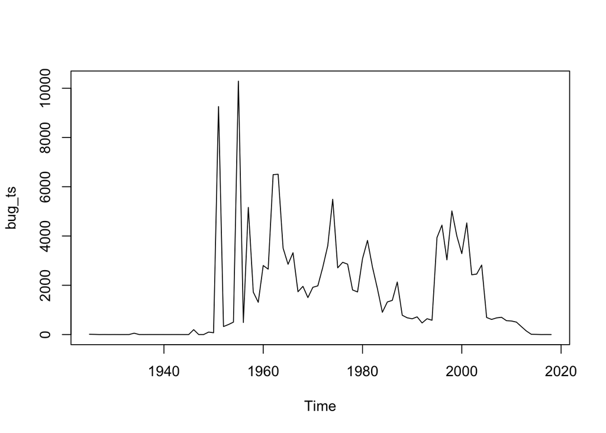

```r
data_nona <- na.omit(data)
agg_tbl <- data_nona %>% group_by(Year) %>%
  summarise(mean_num=mean(Number),
            .groups = 'drop')
bug_ts <- ts(agg_tbl$mean_num, start=1925, end=2018)
plot.ts(bug_ts)
```

```r
range(agg_tbl$mean_num)
```

```
## [1] 2.829648e-02 1.028853e+04
```

- If I want to aggregate some of the data, a problem to deal with is that the mean varies with which data sources are included. This might be able to be dealt with, but I’m not sure how.